# Machine Learning - Class Project

# Overview

This project was created for the Machine Learning class project. The purpose of this project is to evalutate personal fitness data originally found at this website: http://groupware.les.inf.puc-rio.br/har and make predictions about the type of excercise being performed based on the factors in the data. The data from this site was gathered as part of a personal fitness study. Participants in the study were asked to perform weight-lifting excercises in 5 different ways, both correctly and incorrectly.

This project will build models using machine learning algorithms that will predict the exercise based on the data gathered. In an attempt to build the best model possible, cross validation will be used with two different machine learning models. The best machine learning model will then be used for project submittal.

In addition, the covariates of each model will be examined to see if there were signifcant differences between each model. Differences in either the weighting or inclusion of covariates can influence model performance.

```r
#load libraries
library(randomForest)
library(caret)
```

```r
# Set the random number seed for reproducibility
set.seed(1119)

#Load the files ###############################
#Training file
if (!file.exists("pml-training.csv")) {
  download.file("http://d396qusza40orc.cloudfront.net/predmachlearn/pml-training.csv", destfile="pml-training.csv")
}

trainingDF <- read.csv("pml-training.csv", na.strings = c("", "NA", "#DIV/0!"))

#Testing file (this will be known as the validation set)
if (!file.exists("pml-testing.csv")) {
  download.file("http://d396qusza40orc.cloudfront.net/predmachlearn/pml-testing.csv", destfile="pml-testing.csv")
}

validation <- read.csv("pml-testing.csv", na.strings = c("", "NA", "#DIV/0!"))
```

# Cross Validation and Error Rates

# Step 1 - Clean and Process the Data

Getting and cleaning data is a significant part of any data science project, and this one is no different. When some basic exploratory analysis was done on the data (not shown for brevity), it was clear that data cleaning would be needed. Several of the columns contained nothing but “NA” values and could be discarded. In addition, several columns were found to have error (#DIV/0!) values, or blanks. As part of reading in the data into a dataframe, these values were converted to “NA”. Further, after a review of the data, the first few columns in the dataset did not appear to be measurements, but rather something closer to metadata. These columns were discarded so as not to interfere with the prediction.

```r
#Clean the files ###########################

#some columns seem to be just "NA", get rid of the columns with NA in them
blankCols <- colSums(is.na(trainingDF)) > 0

#use the same index of columns for both the training and validation sets so we are consistent
trainingDF <- trainingDF[, !blankCols]
validation <- validation[,!blankCols]

#remove the covariates that are zero or close enough to be just noise
zeroCols <- nearZeroVar(trainingDF)

trainingDF <- trainingDF[,-zeroCols]
validation <- validation[,-zeroCols]

#the first 7 columns appear to be something other than covariates, get rid of them for the analysis
trainingDF <- trainingDF[,-(1:7)]
validation <- validation[,-(1:7)]

#Separate the training data into training and testing
inTrain <- createDataPartition(y=trainingDF$classe, p=0.6, list=FALSE)
training <- trainingDF[inTrain,]
testing <- trainingDF[-inTrain,]
```

# STEP 2 - Model Approach

Two prediction models will be developed for prediction and cross validation. The best model will be selected and run on the validation set. The results of the model run on the validation set will be submitted for the couse project.

## Tree Model

Tree models are easy to interpret and can be generated quickly. However, tree models by themselves can be subject to overfitting. The code below generates a tree model using the caret package on the training dataset. The quality of the predictions is then examined by using the testing dataset.

```r
treeMod <- train(classe ~ ., data=training, method="rpart")
#importance of the difference variables
tImport <- varImp(treeMod, scale = FALSE)

print(tImport)
```

```
## rpart variable importance
##
##   only 20 most important variables shown (out of 51)
##
##                      Overall
## magnet_dumbbell_y     1245.8
## accel_belt_z          1013.2
## gyros_belt_z           970.8
## magnet_belt_y          968.6
## total_accel_belt       845.4
## pitch_forearm          802.0
## magnet_dumbbell_z      708.6
## roll_dumbbell          621.5
## magnet_dumbbell_x      602.5
## yaw_belt               568.7
## pitch_belt             448.5
## total_accel_dumbbell   417.1
## pitch_dumbbell         322.1
## roll_forearm           238.9
## accel_dumbbell_y       223.7
## yaw_dumbbell           217.2
## accel_forearm_x        184.4
## accel_dumbbell_z       179.6
## accel_dumbbell_x       150.7
## accel_arm_z              0.0
```

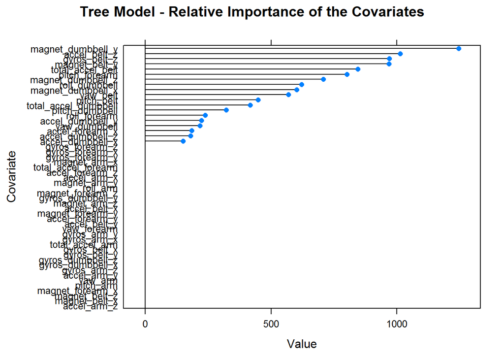

```r
plot(tImport, main="Tree Model - Relative Importance of the Covariates", xlab="Value", ylab="Covariate")
```

```r
#use the tree model and the testing dataset to get a feel of how accurate the constructed
#model is
treePredict <- predict(treeMod, newdata=testing)

tree.test <- confusionMatrix(treePredict, testing$classe)

print(tree.test)
```

```
## Confusion Matrix and Statistics
##
##           Reference
## Prediction    A    B    C    D    E
##          A 1409  263   42   81   24
##          B   24  672   48  122  357
##          C  446  388 1127  385  368
##          D  349  195  151  698  255
##          E    4    0    0    0  438
##
## Overall Statistics
##
##                Accuracy : 0.5537
##                  95% CI : (0.5426, 0.5647)
##     No Information Rate : 0.2845
##     P-Value [Acc > NIR] : < 2.2e-16
##
##                   Kappa : 0.4412
##  Mcnemar's Test P-Value : < 2.2e-16
##
## Statistics by Class:
##
##                      Class: A Class: B Class: C Class: D Class: E
## Sensitivity            0.6313  0.44269   0.8238  0.54277  0.30374
## Specificity            0.9270  0.91293   0.7550  0.85518  0.99938
## Pos Pred Value         0.7746  0.54947   0.4153  0.42354  0.99095
## Neg Pred Value         0.8634  0.87226   0.9530  0.90513  0.86440
## Prevalence             0.2845  0.19347   0.1744  0.16391  0.18379
## Detection Rate         0.1796  0.08565   0.1436  0.08896  0.05582
## Detection Prevalence   0.2318  0.15588   0.3459  0.21004  0.05633
## Balanced Accuracy      0.7791  0.67781   0.7894  0.69898  0.65156
```

**The out of sample error rate** was high for the tree model at 0.45.

## Random Forest Model

Random forest models are computationally expensive, but tend to be accurate. The code below constructs a random forest model.

```r
#Build a random forest model

rForest <- train(classe ~ ., data=training, method="rf")

#importance of the difference variables
rfImport <- varImp(rForest, scale = FALSE)

print(rfImport)
```

```
## rf variable importance
##
##   only 20 most important variables shown (out of 51)
##
##                      Overall
## yaw_belt               876.1
## pitch_forearm          791.8
## pitch_belt             621.7
## magnet_dumbbell_z      594.8
## magnet_dumbbell_y      539.3
## roll_forearm           454.4
## accel_belt_z           366.5
## gyros_belt_z           298.6
## magnet_belt_z          268.7
## accel_dumbbell_y       263.4
## magnet_belt_y          260.1
## magnet_dumbbell_x      241.3
## roll_dumbbell          238.9
## accel_forearm_x        221.5
## accel_dumbbell_z       193.2
## total_accel_dumbbell   192.4
## magnet_forearm_z       186.3
## magnet_belt_x          176.0
## yaw_arm                153.3
## accel_forearm_z        147.2
```

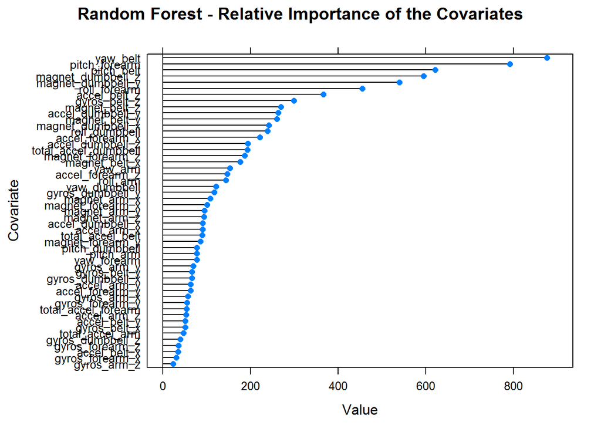

```r
plot(rfImport, main="Random Forest - Relative Importance of the Covariates", xlab="Value", ylab="Covariate")
```

```r
#use the random forest model and the testing dataset to get a feel of how accurate the constructed
#model is
testPredict <- predict(rForest, newdata=testing)

rf.test <- confusionMatrix(testPredict, testing$classe)

print(rf.test)
```

```
## Confusion Matrix and Statistics
##
##           Reference
## Prediction    A    B    C    D    E
##          A 2230   11    0    0    0
##          B    2 1503   17    0    0
##          C    0    4 1345   17    0
##          D    0    0    6 1266    1
##          E    0    0    0    3 1441
##
## Overall Statistics
##
##                Accuracy : 0.9922
##                  95% CI : (0.99, 0.994)
##     No Information Rate : 0.2845
##     P-Value [Acc > NIR] : < 2.2e-16
##
##                   Kappa : 0.9902
##  Mcnemar's Test P-Value : NA
##
## Statistics by Class:
##
##                      Class: A Class: B Class: C Class: D Class: E
## Sensitivity            0.9991   0.9901   0.9832   0.9844   0.9993
## Specificity            0.9980   0.9970   0.9968   0.9989   0.9995
## Pos Pred Value         0.9951   0.9875   0.9846   0.9945   0.9979
## Neg Pred Value         0.9996   0.9976   0.9965   0.9970   0.9998
## Prevalence             0.2845   0.1935   0.1744   0.1639   0.1838
## Detection Rate         0.2842   0.1916   0.1714   0.1614   0.1837
## Detection Prevalence   0.2856   0.1940   0.1741   0.1622   0.1840
## Balanced Accuracy      0.9986   0.9936   0.9900   0.9917   0.9994
```

**The out of sample error rate** for the random forest algorithm was significantly better at approximately 0.01.

## STEP 3 - Conclusion and Submittal

## Conclusion

The tree model has a relatively dismal accuracy rate of approximately 55%. However, the Random Forest model has an accuracy of 99%. The random forest model will be used for the project submission. It is my expectation that the out of sample error rate for the random forest model on the validation set will also be close to 0.01, so there is a reasonable chance of getting all 20 predictions correct.  
It is interesting to note that when the covariate significance of each model was examined with the *varImp()* method, the important covariates were different in each model. This resulted in very different accuracy rates for each model.

When the random forest was run on the validation dataset and the results were submitted, 100% of the predictions were correct.

## Submittal

Run the random forest model on the validation set and submit

```r
#predictions on the validation set
validationPredict <- predict(rForest, newdata=validation)
```

For the problem submission, use the function provided in the submission instructions to write out the predictions in a file.

```r
#generate the files for the problem submission using the provided function
pml_write_files = function(x){
  n = length(x)
  for(i in 1:n){
    filename = paste0("problem_id_",i,".txt")
    write.table(x[i],file=filename,quote=FALSE,row.names=FALSE,col.names=FALSE)
  }
}

pml_write_files(validationPredict)
```